# Assignment 2 - Data Analysis

Author

Nicholas Vietto

# Getting Started

1.) [Head to Posit Cloud](https://posit.cloud/)

2.) Click “Get Started”

3.) Under “Cloud Free” click Learn more

4.) Click Sign Up then fill out the form

5.) Verify your email

6.) Once your in the posit Cloud, click “New Project”

[figure not shown]

7.) Then “New RStudio Project”

[figure not shown]

# Install and Load Libraries

*Write in each line below into the console then hit enter*

You have to write these in, you can’t copy and paste these.

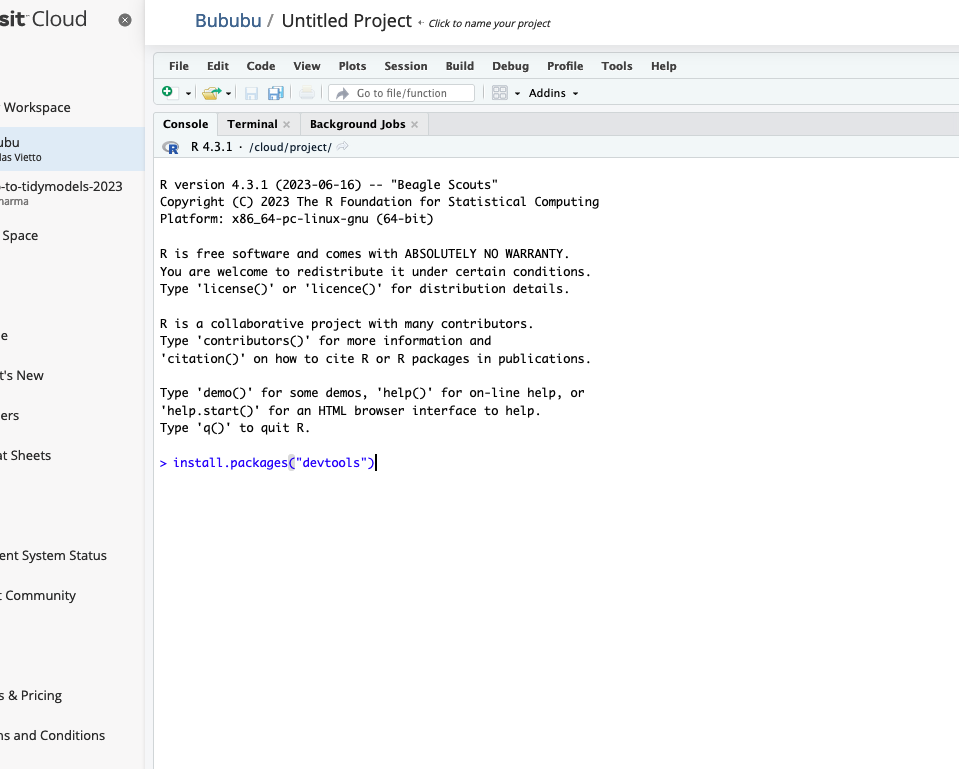

**You have to write these in, you can’t copy and paste these.**

install.packages(“tidyverse”)

install.packages(“devtools”)

install.packages(“palmerpenguins”)

remotes::install_github(“ddsjoberg/gtsummary”)

*Each install will take time to run, so wait until the red stop sign in the corner disappears*

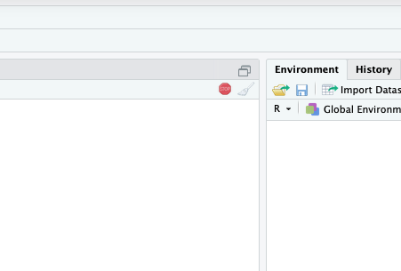

# Load the packages

*Once you finish installing, copy and paste this code below into the console and hit enter*

```r
library(devtools)

library(palmerpenguins)

library(tidyverse)
```

# Views the data sets.

*Copy and paste each of the words below into the console to view the dataframes (i.e., the columns and rows of the data)*

```r
penguins

starwars

USArrests
```

# Analysis

*Copy and paste each code block into the console and screenshot the result. Be sure to use include the blue cloud symbol in each screenshot.*

*1.) Run the following code (copy and paste and hit enter) in the console and screenshot the table (will appear in the viewer on the right)*

```r
library(gtsummary)

tibble(penguins)

summary(penguins)

penguins |>
  select(species, island, sex) |>
  tbl_summary()
```

*2.) Run the following code in the console and screenshot the graph*

```r
speciesmass <- starwars |>
  group_by(species) |>
  summarise(
    n = n(),
    mass = mean(mass, na.rm = TRUE)
  ) %>%
  filter(n > 1)

speciesmass |>
 ggplot(mapping = aes(x = species, y = mass)) +
  geom_point()
```

*3.) Run the following code in the console and screenshot the bar plot*

```r
USArrests |>
  ggplot(mapping = aes(x = UrbanPop, y = Murder)) +
  geom_col() +
  labs(x = "Percent urban population", y = "Murder arrests (per 100,000)")
```

# Submit the screenshots on canvas.

## Congrats! Now you’re a data scientist!

[figure not shown]